# Advanced Statistics for Physics Analysis

## R Lab 05

### Student: Toso Simone (2095484)

```r
library(tidyverse)
library(GoFKernel)
library(ggpubr)
library(rjags)
```

```r
theme <- theme(legend.text = element_text(size = 12), axis.title = element_text(size = 15), axis.text = element_text(size = 15), plot.title = element_text(face = "bold", size = 16))
sc <- scale_colour_manual(values = c("black","firebrick"))
```

### Ex.1

#### Assuming a uniform prior, compute and plot the posterior distribution for λ, the death rate over the measurement time. Determine the posterior mean, median and variance, and compute the 95% credibility interval.

```r
#Observations
deaths_1 <- c(109, 65, 22, 3, 1, 0)
deaths_2 <- c(144, 91, 32, 11, 2, 0)

df <- data.frame(data1 = deaths_1, data2 = deaths_2)
```

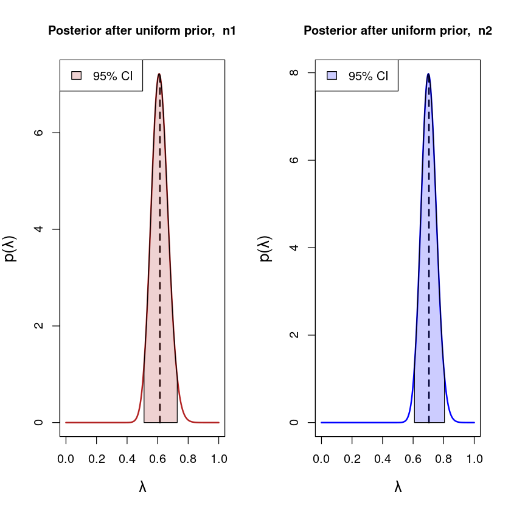

```r
#For each of the two samples compute the posterior

results <- data.frame(matrix(nrow = 0, ncol = 5))
colnames(results) <- c("Mean", "Var", "Median", "CI_lower", "CI_upper")
corps <- c("n1", "n2")

par(mfrow = c(1, 2))  # Plotting space
colors <- c("firebrick", "blue")
for(i in 1:ncol(df)){
    #Posterior will be a Gamma function -> find parameters
    alpha <- 1 + sum(df[,i] * seq(from = 0, to = 5, by = 1))
    lambda <- sum(df[,i])

    #Evaluate mean, median, variance
    mean <- integrate(function(x) dgamma(x, shape = alpha, scale = 1/lambda)*x,0,Inf)$value
    median <- qgamma(0.5, shape = alpha, scale = 1/lambda)
    variance <- integrate(function(x) dgamma(x, shape = alpha, scale = 1/lambda)*(x-mean)^2, 0, Inf)$value

    #Credibility interval
    CI <- c(qgamma(0.025, shape = alpha, scale = 1/lambda), qgamma(0.975, shape = alpha, scale = 1/lambda))

    #Store values
    results[nrow(results) + 1, ] <- c(mean, variance, median, CI[1], CI[2])

    #Plots
    xs <- seq(from = 0, to = 1, length.out = 1001)        # x points
    yplot <- dgamma(xs, shape = alpha, scale = 1/lambda)  # y points

    plot(xs, yplot, type = "l", main = paste("Posterior after uniform prior, ", corps[i]),
        col = colors[i], lwd = 2, xlab = "\u03bb", ylab = "p(\u03bb)", cex.lab = 1.3, cex.main = 1) #curve

    segments(x0 = mean, y0 = 0, x1 = mean, y1 = dgamma(mean, shape = alpha, scale = 1/lambda),
             col="black", lty = 2, lwd = 2) #mean

    color = col2rgb(colors[i], alpha = FALSE)[,1]
    polygon(c(CI[2], CI[2], CI[1], CI[1], xs[xs > CI[1] & xs < CI[2]]),
            c(dgamma(CI[2], shape = alpha, scale = 1/lambda),0, 0, dgamma(CI[1], shape = alpha, scale = 1/lambda), yplot[xs > CI[1] & xs < CI[2]]),
            col =rgb(color[1]/255, color[2]/255, color[3]/255, alpha = 0.2))    #shade CI under curve

    #Legend
    legend("topleft", legend = "95% CI",
           fill = rgb(color[1]/255, color[2]/255, color[3]/255, alpha = 0.2) )

}
```

```r
#Display results
rownames(results) <- c("n1", "n2")
results
```

A data.frame: 2 × 5

|  | Mean <dbl> | Var <dbl> | Median <dbl> | CI_lower <dbl> | CI_upper <dbl> |
| --- | --- | --- | --- | --- | --- |
| n1 | 0.6150000 | 0.003075000 | 0.6133341 | 0.5111251 | 0.7283408 |
| n2 | 0.7035714 | 0.002512755 | 0.7023813 | 0.6087487 | 0.8051570 |

#### Assuming now a Jeffreys’ prior, g(λ) ∝ 1/√λ , with λ > 0, compute and plot the posterior distribution for λ, the death rate over the measurement time. Determine the posterior mean, median and variance, and compute the 95% credibility interval.

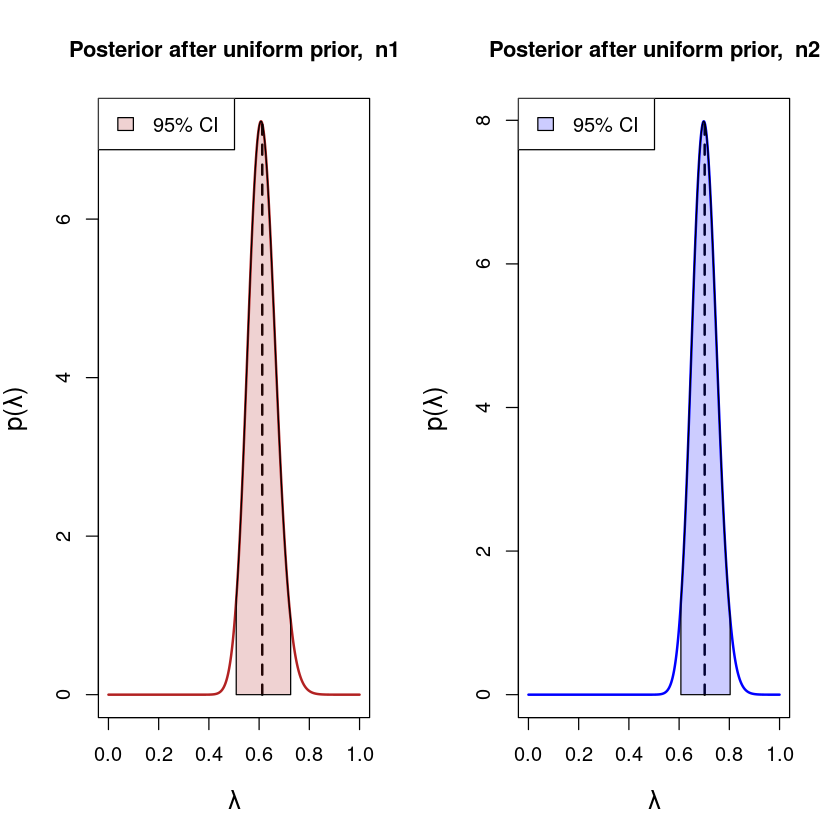

```r
#Same as before, but with 1/2 instead of 1
df <- data.frame(data1 = deaths_1, data2 = deaths_2)

#For each of the two samples compute the posterior lambda^{sum x_i} e^{-n_dati lambda}

results <- data.frame(matrix(nrow = 0, ncol = 5))
colnames(results) <- c("Mean", "Var", "Median", "CI_lower", "CI_upper")
corps <- c("n1", "n2")

par(mfrow = c(1, 2))  # Plotting space

for(i in 1:ncol(df)){
    #Posterior will be a Gamma function -> find parameters
    alpha <- 1/2 + sum(df[,i] * seq(from = 0, to = 5, by = 1))
    lambda <- sum(df[,i])

    #Evaluate mean, median, variance
    mean <- integrate(function(x) dgamma(x, shape = alpha, scale = 1/lambda)*x,0,Inf)$value
    median <- qgamma(0.5, shape = alpha, scale = 1/lambda)
    variance <- integrate(function(x) dgamma(x, shape = alpha, scale = 1/lambda)*(x-mean)^2, 0, Inf)$value

    #Credibility interval
    CI <- c(qgamma(0.025, shape = alpha, scale = 1/lambda), qgamma(0.975, shape = alpha, scale = 1/lambda))

    #Store values
    results[nrow(results) + 1, ] <- c(mean, variance, median, CI[1], CI[2])

    #Plots
    xs <- seq(from = 0, to = 1, length.out = 1001)        # x points
    yplot <- dgamma(xs, shape = alpha, scale = 1/lambda)  # y points

    plot(xs, yplot, type = "l", main = paste("Posterior after uniform prior, ", corps[i]),
        col = colors[i], lwd = 2, xlab = "\u03bb", ylab = "p(\u03bb)", cex.lab = 1.3, cex.main = 1.1) #curve

    segments(x0 = mean, y0 = 0, x1 = mean, y1 = dgamma(mean, shape = alpha, scale = 1/lambda),
             col="black", lty = 2, lwd = 2) #mean

    color = col2rgb(colors[i], alpha = FALSE)[,1]
    polygon(c(CI[2], CI[2], CI[1], CI[1], xs[xs > CI[1] & xs < CI[2]]),
            c(dgamma(CI[2], shape = alpha, scale = 1/lambda),0, 0, dgamma(CI[1], shape = alpha, scale = 1/lambda), yplot[xs > CI[1] & xs < CI[2]]),
            col =rgb(color[1]/255, color[2]/255, color[3]/255, alpha = 0.2))    #shade CI under curve

    #Legend
    legend("topleft", legend = "95% CI",
           fill = rgb(color[1]/255, color[2]/255, color[3]/255, alpha = 0.2) )
}
```

```r
#Display results
rownames(results) <- c("n1", "n2")
results
```

A data.frame: 2 × 5

|  | Mean <dbl> | Var <dbl> | Median <dbl> | CI_lower <dbl> | CI_upper <dbl> |
| --- | --- | --- | --- | --- | --- |
| n1 | 0.6125000 | 0.003062500 | 0.6108341 | 0.5088464 | 0.7256196 |
| n2 | 0.7017857 | 0.002506378 | 0.7005956 | 0.6070878 | 0.8032465 |

### Ex. 2

#### Solve Exercise 1 with a Markov Chain Monte Carlo. Build your own MCMC, using the functions introduced during lectures, or using a MCM library like JAGS

```r
#Observations
obs_n1 <- c(rep(0,109),rep(1,65),rep(2,22),rep(3,3),rep(4,1))
obs_n2 <- c(rep(0,144),rep(1,91),rep(2,32),rep(3,11),rep(4,2))
```

##### Uniform prior, n1

```r
#Uniform brior --> find posterior distribution

#Initialize data for Jags, as seen in class
data <- NULL
data$X <- obs_n1
data$n <- length(obs_n1)

#Model creation
jm <- jags.model('horse.bug', data)
```

```r
#Burn-in
update(jm, 5000)

#Samples
chain <- coda.samples (jm , c("lambda"), n.iter=40000)

#Show
print(summary(chain))
```

```
Iterations = 6001:46000
Thinning interval = 1
Number of chains = 1
Sample size per chain = 40000

1. Empirical mean and standard deviation for each variable,
   plus standard error of the mean:

          Mean             SD       Naive SE Time-series SE
     0.6146668      0.0555747      0.0002779      0.0003546

2. Quantiles for each variable:

  2.5%    25%    50%    75%  97.5%
0.5108 0.5761 0.6129 0.6514 0.7287
```

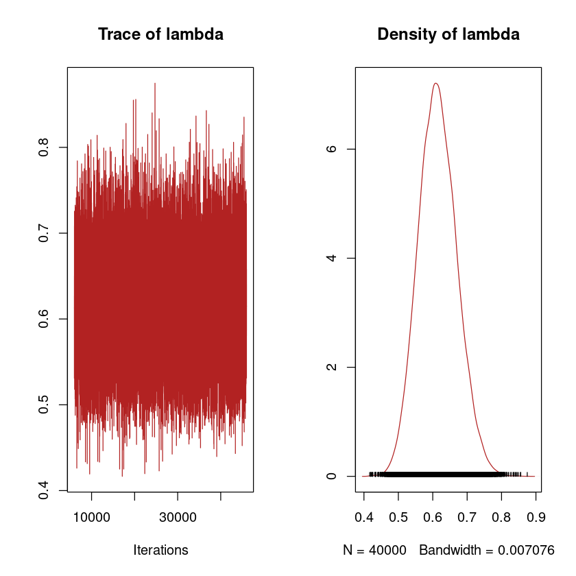

```r
plot(chain, col = colors[1])
```

##### Uniform prior, n2

```r
data <- NULL
data$X <- obs_n2
data$n <- length(obs_n2)

jm <- jags.model("horse.bug", data)
```

```
Iterations = 6001:46000
Thinning interval = 1
Number of chains = 1
Sample size per chain = 40000

1. Empirical mean and standard deviation for each variable,
   plus standard error of the mean:

          Mean             SD       Naive SE Time-series SE
     0.7030391      0.0502116      0.0002511      0.0003244

2. Quantiles for each variable:

  2.5%    25%    50%    75%  97.5%
0.6080 0.6688 0.7018 0.7362 0.8047
```

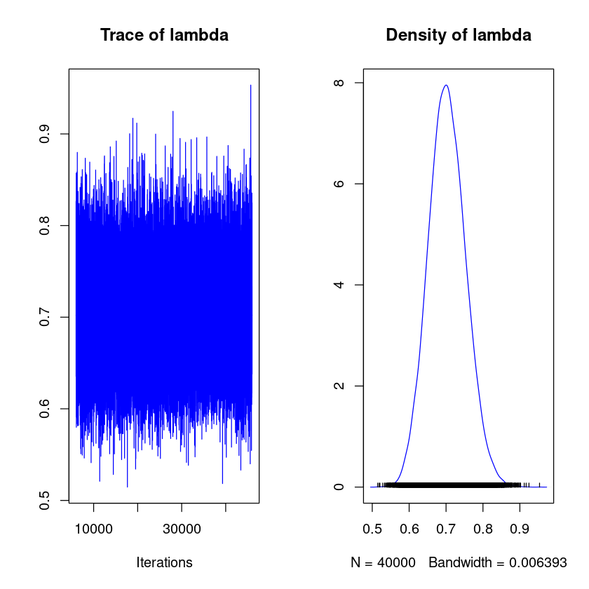

```r
update(jm, 5000)
chain <- coda.samples (jm , c("lambda"), n.iter=40000)

#Plot
plot(chain, col = colors[2])

#Show
print(summary(chain))
```

### Ex. 3

#### A study on water quality of streams, a high level of bacteria X was defined as a level greater than 100 per 100 ml of stream water. n = 116 samples were taken from streams having a high environmental impact on pandas. Out of these, y = 11 had a high bacter X level. indicating with p the probability that a sample of water taken from the stream has a high bacter X level

#### a) Find a frequentist estimator for $p$

```r
n <- 116 #number of samples
y <- 11 #number of samples with high level of bacterium

p <- y/n #Frequentist estimator
print(paste("Frequentist estimator: y/n = ", p))
```

```
[1] "Frequentist estimator: y/n =  0.0948275862068965"
```

#### b) Using a Beta(1, 10) prior for p, calculate and posterior distribution P (p|y)

```r
# P(p|y) proportional to P(y|p)P(p)
posterior <- function(x){
    return(dbeta(x,1,10) * x^(y) * (1-x)^(n-y) ) # P(y|p) proportional to p^y (1-p)^(n-y)
}
posterior <- Vectorize(posterior)
Z_posterior <- integrate(posterior, 0, 1)$value
```

#### (c) Find the bayesian estimator for p, the posterior mean and variance, and a 95% credible interval

```r
#A bayesian estimator for p is given by the mean of the posterior distribution, E[p].

mean <- integrate(function(x) x*posterior(x)/Z_posterior, 0, 1)$value
var <- integrate(function(x) x^2 * posterior(x)/Z_posterior, 0, 1)$value - mean^2

#We know from the theory that the posterior can be expressed as Beta(1 + y, 10 + n − y)
CI <- c(0.025 %>% qbeta(1+y,10+n-y), 0.975 %>% qbeta(1+y,10+n-y))
```

```r
results <- data.frame(mean, var, CI[1], CI[2])
colnames(results) <- c("Mean", "Var", "CI_lower", "CI_upper")

results
```

A data.frame: 1 × 4

| Mean <dbl> | Var <dbl> | CI_lower <dbl> | CI_upper <dbl> |
| --- | --- | --- | --- |
| 0.09448823 | 0.0006684349 | 0.05018522 | 0.1508379 |

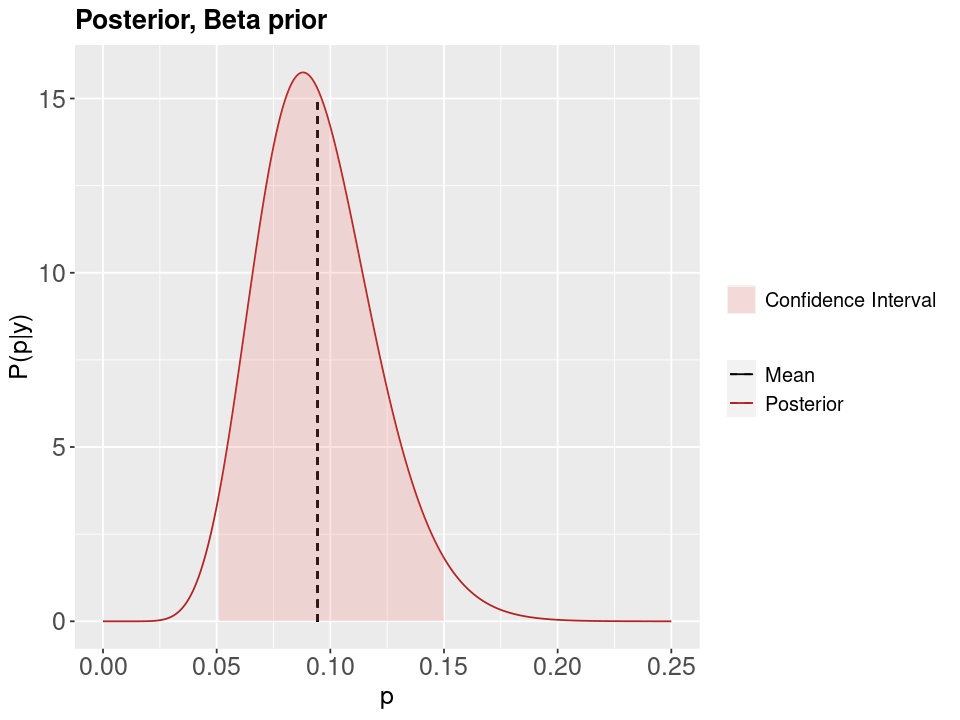

```r
#Plot
xs = seq(from = 0, to = 1, length.out = 1001)
df = data.frame(xs, ys = dbeta(x = xs, 1+y, 10+n-y))

p <- ggplot(df) + geom_line(aes(x = xs, y = ys, color = "Posterior")) + ggtitle("Posterior, Beta prior") + theme
p <- p + geom_segment(aes(x = mean, y = 0, xend = mean, yend = 15, color = "Mean"), linetype = "dashed")
p <- p + geom_ribbon(data=subset(df ,xs>=CI[1] & xs<=CI[2]),aes(x = xs,ymax=ys, fill="Confidence Interval"),ymin=0,colour=NA,alpha=0.2)
p <- p + labs(x = "p", y = "P(p|y)", color = NULL, fill = NULL)

options(repr.plot.width=8, repr.plot.height=6)
p + sc + xlim(0,0.25)
```

#### d) Test the hypotesis H0 : $p = 0.1$ versus H1 : $p\neq0.1$ at 5% level of significance with both the frequentist and bayesian approach

##### Frequentist approach

$H_0: p = 0.1$ $H_1: p!= 0.1$ We measure $y$ contaminated samples. If $H_0$ holds true, then the distribution of $y$ will be a binomial with $p=0.1$.

```r
#I write it as a function, because I will also need it later in point h.
frequentist_approach <- function(y_func,n_func, color){
    xs <- seq(from = 0, to = n_func, by = 1)
    values <- dbinom(xs, size = n_func, prob = 0.1) #binomial distribution
    df <- data.frame(xs, values)

    #Two sided --> find approximately 0.025 on one side and 0.975 on the other
    cumulatives <- rep(0, length(values))
    cumulatives[1] = values[1]
    for(i in 2:length(values)){
        cumulatives[i] <- cumulatives[i-1] + values[i]
    }
    cumulatives <- unlist(cumulatives)

    ##Find first entry in cumulatives >= 0.025, and check the previous value. Choose the value closest to 0.025
    indeces_min <- c(min(which(cumulatives >= 0.025))-1, min(which(cumulatives >= 0.025)))
    indeces_max <- c(max(which(cumulatives <= 0.975)), max(which(cumulatives <= 0.975))+1)

    if(abs(cumulatives[indeces_min[1]] - 0.025) < abs(cumulatives[indeces_min[2]]-0.025)){
        indeces_min <- indeces_min[1]
    }
    else{
        indeces_min <- indeces_min[2]
    }

    if(abs(cumulatives[indeces_max[1]] - 0.975) < abs(cumulatives[indeces_max[2]]-0.975)){
        indeces_max <- indeces_max[1]
    }
    else{
        indeces_max <- indeces_max[2]
    }

    x_min <- xs[indeces_min]
    x_max <- xs[indeces_max]

    alpha_used = cumulatives[indeces_min] + (1 - cumulatives[indeces_max])

    print(paste("First point in acceptance region: ", x_min))
    print(paste("Last point in acceptance region: ", x_max))

    print(paste("Alpha used: ", alpha_used))

    print(paste("Lower tail integral: ", cumulatives[indeces_min]))
    print(paste("Upper tail integral: ", cumulatives[indeces_max]))

    #Plot and show where our observation lands. Change colour to highlight acceptance region
    x_barplot = seq(from = 0, to = 30, by = 1)

    colours = rep("white", length(x_barplot))                # only plot from 0 to x_max + 5 to "zoom in"
    colours[x_barplot >= x_min & x_barplot <= x_max] = color # acceptance region

    barplot(dbinom(x_barplot, n_func, 0.1), col = colours,
            names.arg = seq(from = 0, to = x_barplot[length(x_barplot)], by = 1),
            main = paste("Binomial distribution with p = 0.1, n = ", n_func, ", observation = ", y_func),
           xlab="y", ylab="P(y|p = 0.1)", cex.lab = 1.2, las=2) #binomial, restricted to [0,35] for plotting

    #Add legend
    legend("topright", legend = c("Acceptance region", "Rejection region"), fill = c(color, "white") )

}
```

```
[1] "First point in acceptance region:  5"
[1] "Last point in acceptance region:  18"
[1] "Alpha used:  0.0425434770929675"
[1] "Lower tail integral:  0.02092518338129"
[1] "Upper tail integral:  0.978381706288323"
```

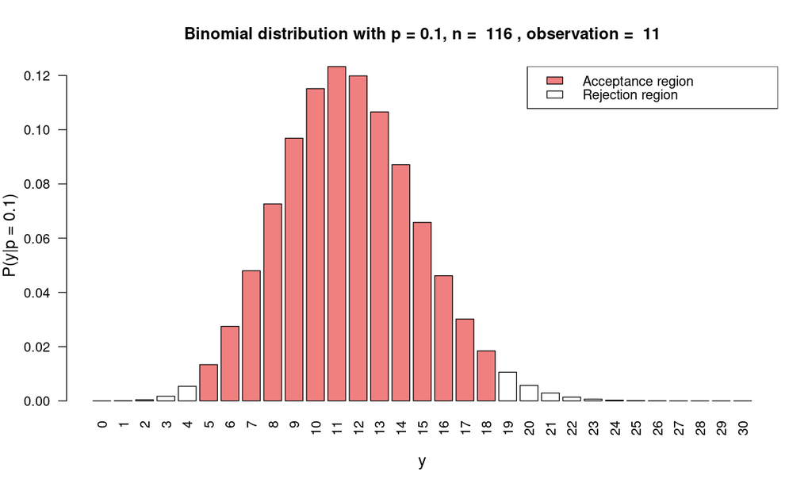

```r
options(repr.plot.width=10, repr.plot.height=6)

frequentist_approach(y,n,"lightcoral")
```

The observation $y=11$ is well inside the acceptance region, so we don't reject the null hypothesis.

##### Bayesian approach

Check if $p=0.1$ lies in our credibility interval

```r
CI
```

1. 0.0501852163002454

2. 0.150837921271285

The credibility interval contains $p=0.1$, so we can't reject $H_0$.

#### A new measurement, performed one month later on n = 165 water samples, gives y = 9 high bacter X level

#### e) Find the frequentist estimator for p

```r
y_new <- 9
n_new <- 165

#Frequentist estimator
p_est <- y_new/n_new
print(paste("y/n = ", p_est))
```

```
[1] "y/n =  0.0545454545454545"
```

#### f) Find a bayesian estimator for p, assuming both a Beta(1, 10) prior for p, and assuming the posterior probability of the older measurement as the prior for the new one

```r
#Beta(1,10) --> Beta(1+y_new, 10 + n_new - y_new) --> mean = alpha / (alpha + beta)
mean_beta_prior <- (1 + y_new)/(1 + 10 + n_new)
print(paste("Mean with Beta(1, 10) prior: ", mean_beta_prior))
```

```
[1] "Mean with Beta(1, 10) prior:  0.0568181818181818"
```

We do the case in which the prior is the previous posterior in the next point.

#### g) Find the bayesian estimator for p, the posterior mean and variance, and a 95% credible interval

We do it by keeping the previous posterior as the new prior.

For the old measurement, the posterior was a Beta distribution: $B(1+y, 10+n-y)$. Now again we will once again find a Beta distribution: $B(1+y+y_{new}, 10+n-y+n_{new}-y_{new})$

```r
#a,b parameters of posterior
a_posterior <- 1 + y + y_new
b_posterior <- 10 + n - y + n_new - y_new

#Mean, std, CI
mean_new <- a_posterior/(a_posterior + b_posterior)
var_new <- a_posterior*b_posterior/((a_posterior + b_posterior)^2*(a_posterior + b_posterior + 1))
CI_new <- c(qbeta(0.025, a_posterior, b_posterior), qbeta(0.975, a_posterior, b_posterior))

print(paste("Mean: ", mean))
print(paste("Std: ", sqrt(var)))
print(paste("CI: ", CI[1], CI[2]))
```

[output not shown]

#### h) test the hypotesis $H_0: p = 0.1 $ versus $ H1 : p \neq 0.1$ at 5% level of significance with both the frequentist and bayesian approach

##### Frequentist approach

```
[1] "First point in acceptance region:  9"
[1] "Last point in acceptance region:  24"
[1] "Alpha used:  0.0511155012915149"
[1] "Lower tail integral:  0.0274603966787877"
[1] "Upper tail integral:  0.976344895387273"
```

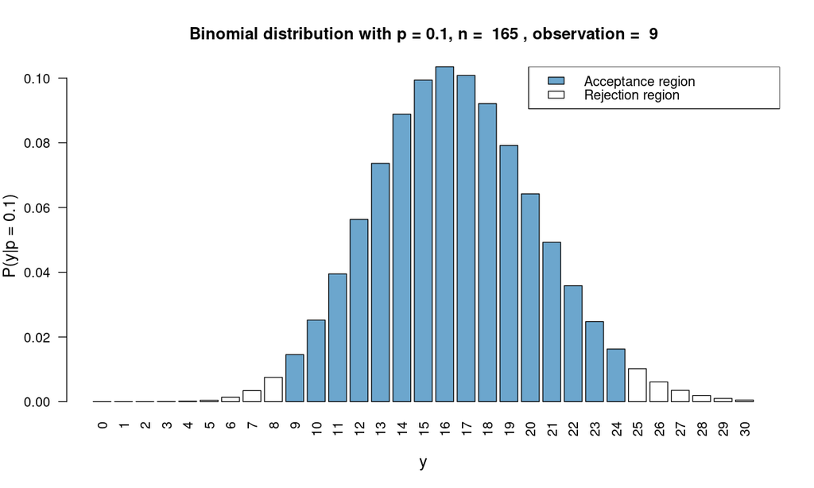

```r
frequentist_approach(y_new, n_new, "skyblue3")
```

We can't reject the null hypothesis $H_0: p = 0.1$, since the observed value $y=9$ is just inside the acceptance region. In this case, however, it would be better not to make a strong statement before getting more data, since if $y$ was just one unit less it would be outside of the acceptance region.

##### Bayesian approach

```r
CI_new
```

1. 0.0452235636236437

2. 0.104151949413949

$p=0.1$ is just inside the confidence interval, so we don't reject the null hypothesis.

### Ex.4

#### Use rJAGS to find the posterior for the previous exercise, with mean, variance and CI.

```r
#Ðata
y <- 11   # contaminated samples
n <- 116  # total samples
observations <- c(rep(1, y), rep(0, n - y)) # observed data

#Initialize data for Jags, as seen in class
data <- NULL
data$X <- observations
data$n <- n

#Model creation
jm <- jags.model('bacterium.bug', data)
```

```r
#Burn-in
update(jm, 5000)

#Samples
chain <- coda.samples (jm , c("p"), n.iter=40000)

#Show
print( summary (chain ))
```

```
Iterations = 5001:45000
Thinning interval = 1
Number of chains = 1
Sample size per chain = 40000

1. Empirical mean and standard deviation for each variable,
   plus standard error of the mean:

          Mean             SD       Naive SE Time-series SE
     0.0943550      0.0258668      0.0001293      0.0001293

2. Quantiles for each variable:

   2.5%     25%     50%     75%   97.5%
0.04979 0.07590 0.09232 0.11065 0.15033
```

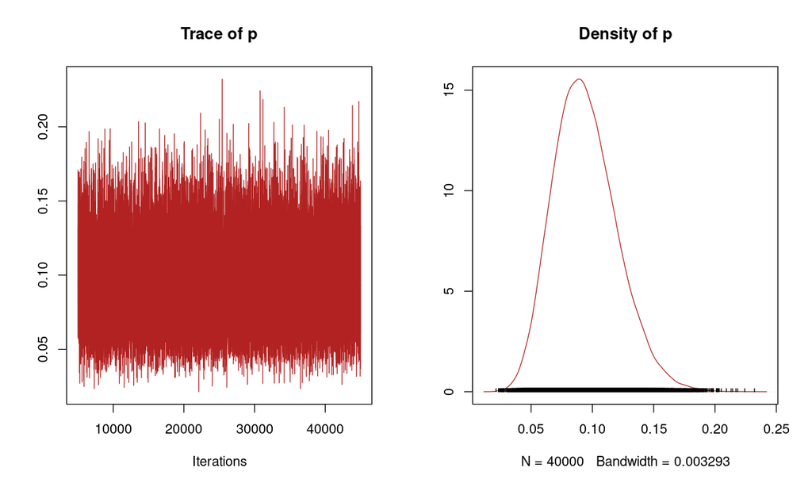

```r
plot(chain, col = "firebrick")
```

```r
summary(chain)
```

```
Iterations = 5001:45000
Thinning interval = 1
Number of chains = 1
Sample size per chain = 40000

1. Empirical mean and standard deviation for each variable,
   plus standard error of the mean:

          Mean             SD       Naive SE Time-series SE
     0.0943550      0.0258668      0.0001293      0.0001293

2. Quantiles for each variable:

   2.5%     25%     50%     75%   97.5%
0.04979 0.07590 0.09232 0.11065 0.15033
```